# TP1 - Modelado Estadistico

Austin Animal Center

Emiliano Torres y Federico Leonardis Ayala

2026-06-27

## Exploración inicial

El dataset contiene **137.806 animales** ( 77.629 perros y 60.177 gatos). Tras una inspección, se verificó la consistencia entre `animal_type` y `dog`, y no se detectaron valores faltantes en ninguna variable. Se observa además que 97.8% de los registros tienen valores no enteros en `los`, lo que indica que esta variable no se contabilizó como días completos.

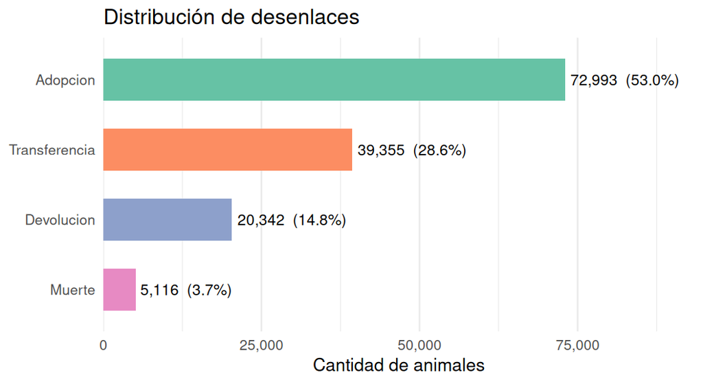

Distribución de los cuatro desenlaces posibles.

La adopción es el desenlace más frecuente (53% de los casos), seguida por transferencia (28,6%). La muerte representa el desenlace menos frecuente (3,7%).

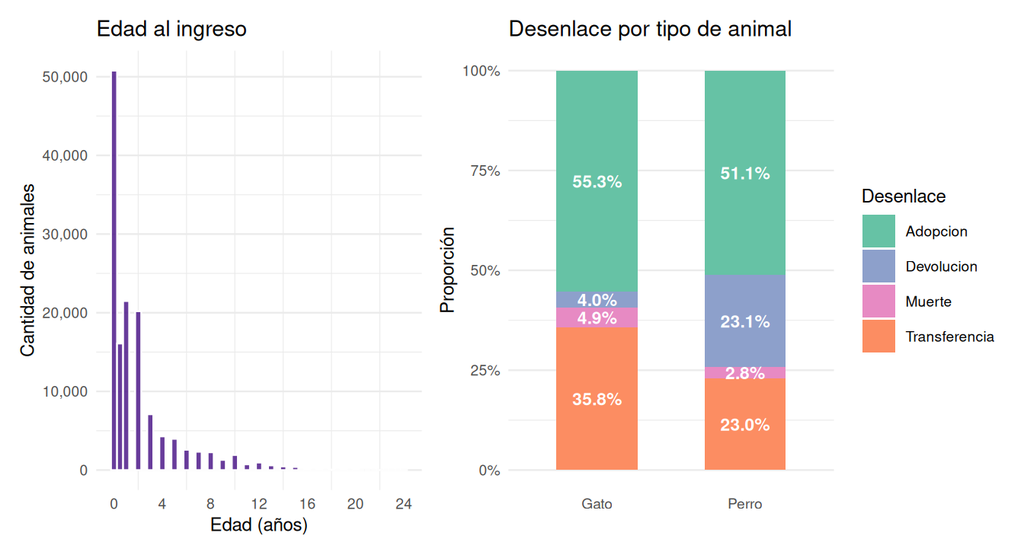

Izquierda: distribución de la edad al ingreso. Derecha: composición de desenlaces por tipo de animal.

La distribución de edad (Figura 2, izquierda) es marcadamente asimétrica: la mayoría de los animales ingresa en sus primeros meses de vida.

En cuanto al tipo de animal (Figura 2, derecha), la composición de desenlaces difiere notablemente: las devoluciones son un fenómeno casi exclusivo de los perros (23,1% vs 4% en gatos), mientras que las transferencias tienen mayor peso relativo en los felinos (35,8% vs 23%).

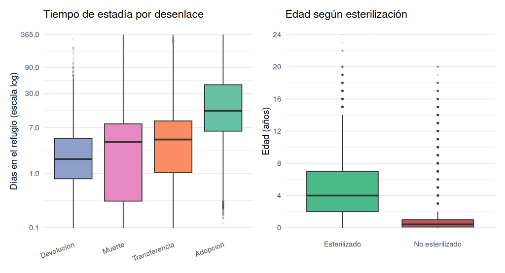

Izquierda: tiempo de estadía por desenlace en escala logarítmica. Derecha: edad al ingreso según condición de esterilización.

Finalmente (Figura 3, derecha), se observa una relación entre esterilización y edad: los animales no esterilizados al ingreso son predominantemente cachorros (mediana = 5 meses), mientras que los esterilizados son adultos (mediana = 4 años).

–

## Ejercicio 2

## Estimación de la tasa de adopción por raza

El objetivo de este ejercicio es evaluar si el estimador de Empirical Bayes mejora la estimación de la tasa de adopción por raza cuando solo se dispone de una muestra pequeña de datos.

### Tasa verdadera por raza

Definimos la tasa “verdadera” de cada raza como su tasa de adopción calculada sobre todos los animales del dataset. Para que esta referencia sea confiable, nos quedamos solo con las razas que tienen al menos 100 animales, resultando en **120 razas**.

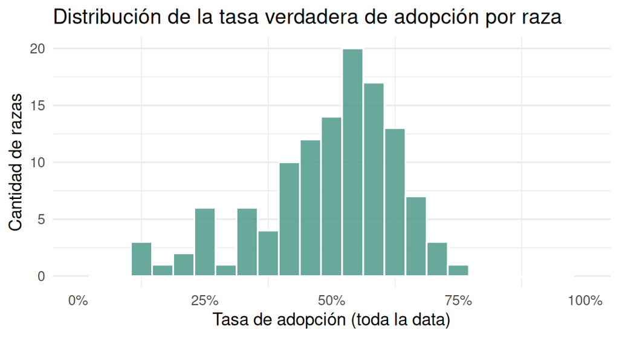

Figura 4. Distribución de la tasa verdadera de adopción entre razas.

La distribución de tasas verdaderas (Figura 4) es aproximadamente unimodal y concentrada entre 40% y 70%, con media 49.2%. Esta forma justifica el uso de una distribución Beta como prior.

### Simulación con muestra pequeña y estimador Empirical Bayes

Para simular el problema de estimación con poca data, tomamos una muestra aleatoria de $m = 15$ animales por raza y calculamos la **tasa cruda** (adoptados / $m$). Con tan pocos datos, esta estimación es muy ruidosa.

Para mejorarla, ajustamos una prior $\text{Beta}(\alpha_0, \beta_0)$ sobre las tasas muestrales usando máxima verosimilitud, obteniendo $\alpha_0 = 2.13$ y $\beta_0 = 2.2$, con media 49.2%. El estimador de Empirical Bayes combina la prior con los datos observados:

$$\hat{p}^{EB}_i = \frac{\alpha_0 +
\text{adoptados}_i}{\alpha_0 + \beta_0 + m}$$

Este estimador aplica *shrinkage*: encoge las tasas crudas extremas hacia la media de la prior, reduciendo el error cuando la muestra es pequeña.

### Comparación de estimadores

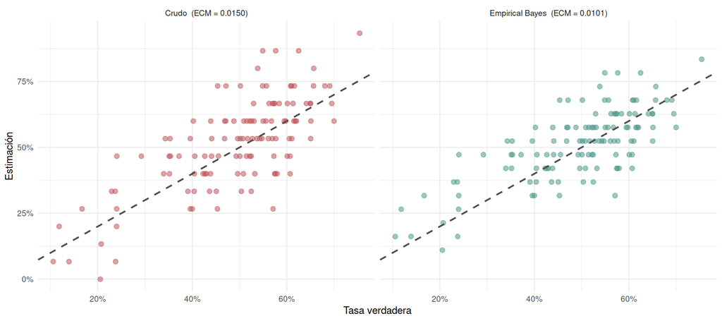

Figura 5. Estimaciones vs tasa verdadera para ambos estimadores. La línea punteada es la identidad (estimación perfecta).

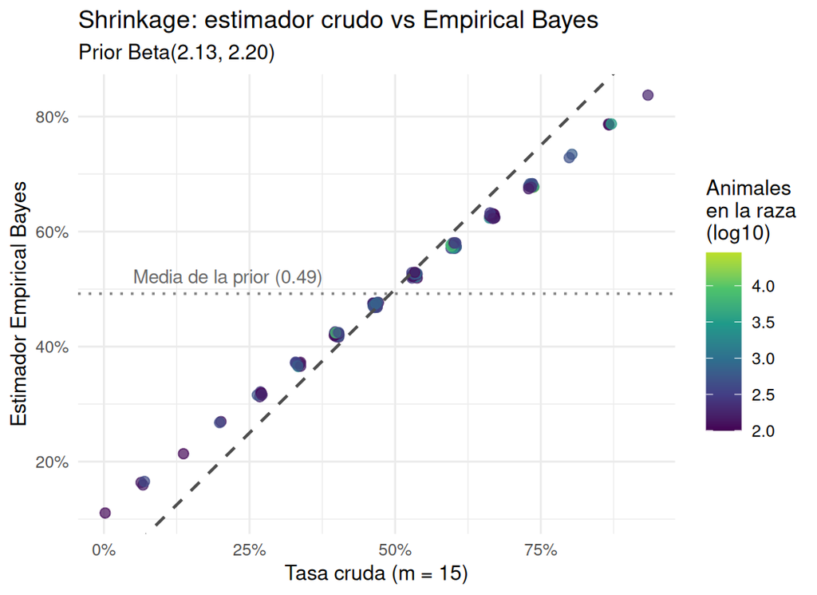

Figura 6. Shrinkage: el estimador EB encoge las tasas crudas hacia la media de la prior. Puntos por encima de la diagonal indican corrección hacia arriba; por debajo, hacia abajo.

La Figura 5 muestra que el estimador crudo tiene mucha dispersión alrededor de la diagonal con $m = 15$ la tasa cruda es muy ruidosa. El estimador de Empirical Bayes reduce considerablemente esa dispersión, con un ECM de 0.0101 vs 0.015 del estimador crudo una reducción del 32.6%.

La Figura 6 ilustra el mecanismo: todos los puntos se acercan a la línea horizontal de la media de la prior (49.2%). Las razas con tasa cruda baja son corregidas hacia arriba y las de tasa cruda alta hacia abajo. Como $m$ es fijo para todas las razas, el shrinkage es uniforme a diferencia del caso clásico donde el encogimiento sería mayor para grupos con menos observaciones.

–

## Ejercicio 3

El modelo multinomial permite estimar las probabilidades de ocurrencia de $K$ resultados distintos y finitos. Definimos $P_i$ como la probabilidad de ocurrencia del $i$-ésimo evento, con $i=1,\dots,K$. Como estas probabilidades deben sumar 1, no podemos modelarlas de manera completamente independiente: conocer $K-1$ de ellas determina automáticamente la restante.

Por este motivo, en el modelo multinomial se suele elegir una categoría de referencia. Luego, para cada categoría $i$ distinta de la referencia, se modela el cociente entre su probabilidad y la probabilidad de la categoría base:

$$\log\left(\frac{P_i}{P_{referencia}}\right)=\beta_i^t \bar{x}$$

donde $\bar{x}$ es el vector de variables explicativas y $\beta_i$ es el vector de coeficientes asociado a la categoría $i$. Notemos que cada categoría tiene sus propios coeficientes, por lo que el efecto de una variable explicativa puede ser distinto según que categoría estemos comparando contra la referencia.

La función logaritmo actúa como función de link. Su rol es transformar un cociente de probabilidades, que solo puede tomar valores positivos, en un valor real. De forma equivalente, podemos escribir:

$$\frac{P_i}{P_{referencia}}=\exp(\beta_i^t \bar{x})$$

Así, cada categoría tiene asociado un score positivo dado por la exponencial de una combinación lineal. Sin embargo, estos scores todavía no son probabilidades, porque no necesariamente suman 1. Para obtener probabilidades válidas, se normalizan mediante una función tipo softmax, tomando la categoria de referencia a ‘K’ y usando que la suma de probabilidades es 1.

$$P_i=P_{K} \exp(\beta_i^t \bar{x})$$
$$P_K.(1+\sum_{j=1}^{K-1}\exp(\beta_j^t \bar{x})) = 1$$
$$P_K = \frac{1}{1+\sum_{j=1}^{K-1}\exp(\beta_j^t \bar{x})}$$

Luego el resto de las $P_i$ es:
$$P_i = \frac{\exp(\beta_i^t \bar{x})}{1+\sum_{j=1}^{K-1}\exp(\beta_j^t
\bar{x})}
\quad \text{para } i=1,\dots,K-1$$
De esta manera, todas las probabilidades son positivas y además suman 1.

```
## Call:
## multinom(formula = desenlace ~ age_years + dog + sterilized +
##     sexo, data = datos)
##
## Coefficients:
##               (Intercept)  age_years        dog sterilized    sexoMacho
## Devolucion     -3.4747739 0.16620766  1.7009305  1.2524363  0.273606391
## Muerte         -2.8917130 0.24281216 -0.7075794 -0.3782199  0.258220482
## Transferencia  -0.4905999 0.08090993 -0.4257549 -0.2241343 -0.002062547
##
## Std. Errors:
##               (Intercept)   age_years        dog sterilized  sexoMacho
## Devolucion     0.02582119 0.003122218 0.02393564 0.02058795 0.01763917
## Muerte         0.02725511 0.004620294 0.03022470 0.04236217 0.02956384
## Transferencia  0.01115315 0.003120335 0.01283847 0.02029064 0.01257725
##
## Residual Deviance: 275489.1
## AIC: 275519.1
```

Primero, estamos viendo los $\beta$ del modelo multinomial escrito de esta forma:

$$\log\left(\frac{P_i}{P_{referencia}}\right)=\beta_i^t \bar{x}$$

Pero para interpretar los resultados preferimos esta expresión:

$$\frac{P_i}{P_{referencia}}=\exp(\beta_i^t \bar{x})$$

–

# Ejercicio 4

$$\widehat{\lambda_j}=\frac{\#adoptados_j}{\#observados_j}$$

Con esto podemos estimar la función de supervivencia de la siguiente manera.

$$\widehat{S}(t_j)=\prod_{t=1}^{j}(1-\widehat{\lambda_j})$$

Recordemos la definición planteada en clase del modelo de hazard proporcionales.
$$\lambda_i(t \mid x) = h_0(t)e^{\beta^T x}$$
Tenemos $\lambda_i$ la probabilidad de morir en el instante t dado las covariables x. $h_0(t)$ el hazard baseline del individuo, que representa el hazard cuando todas las covariables valen 0. Y donde nos vamos a enfocar en este análisis es el factor de riesgos proporcionales. Una variable esta asociada a un tiempo de adopción mas rápido si $e^{\beta}>1$. Para ver esto vamos a fitear un modelo de supervivencia para luego fittear el modelo cox para luego observar la columna exp(coef) del summary.

```
## Call:
## coxph(formula = Surv(los, evento_adopcion) ~ age_years + dog +
##     sterilized + sexo, data = datos)
##
##   n= 137806, number of events= 72993
##
##                 coef exp(coef)  se(coef)       z Pr(>|z|)
## age_years  -0.096162  0.908317  0.002192 -43.867  < 2e-16 ***
## dog         0.328972  1.389538  0.007769  42.343  < 2e-16 ***
## sterilized  0.085512  1.089275  0.012087   7.075 1.50e-12 ***
## sexoMacho  -0.054349  0.947102  0.007417  -7.328 2.34e-13 ***
## ---
## Signif. codes:  0 '***' 0.001 '**' 0.01 '*' 0.05 '.' 0.1 ' ' 1
##
##            exp(coef) exp(-coef) lower .95 upper .95
## age_years     0.9083     1.1009    0.9044    0.9122
## dog           1.3895     0.7197    1.3685    1.4109
## sterilized    1.0893     0.9180    1.0638    1.1154
## sexoMacho     0.9471     1.0559    0.9334    0.9610
##
## Concordance= 0.583  (se = 0.001 )
## Likelihood ratio test= 3617  on 4 df,   p=<2e-16
## Wald test            = 3213  on 4 df,   p=<2e-16
## Score (logrank) test = 3223  on 4 df,   p=<2e-16
```